# Assignment 3 - machine learning methods for solving real-world regression problems and good practice techniques in Data Science

```python
import os
import re
import sys
import torch
import urllib
import shutil
import pathlib
import numpy as np
import pandas as pd
import matplotlib.pyplot as plt
from pprint import pprint

%load_ext autoreload
%autoreload 2
plt.rcParams.update({'font.size': 15,'axes.labelsize' : 15})
device = torch.device('cuda' if torch.cuda.is_available() else 'cpu')
print('Using device:', device)
# !nvidia-smi
```

## Part (I) Univariate data and linear regression

### 1. (8 points)Importing the data

```python
# we upload the data file to github to
DATA_URL_1 = 'https://raw.githubusercontent.com/afiretony/NLDML_hw3/main/data/hw3_ex1.csv'
DATA_URL_2 = 'https://raw.githubusercontent.com/afiretony/NLDML_hw3/main/data/hw3_ex2.csv'
DATA_DIR = pathlib.Path.home().joinpath('datasets')

def download_data(out_path=DATA_DIR, url=DATA_URL_1, force=False):
    pathlib.Path(out_path).mkdir(exist_ok=True)
    out_filename = os.path.join(out_path, os.path.basename(url))

    if os.path.isfile(out_filename) and not force:
        print(f'DATA {out_filename} exists, skipping download.')
    else:
        print(f'Downloading {url}...')
        with urllib.request.urlopen(url) as response, open(out_filename, 'wb') as out_file:
            shutil.copyfileobj(response, out_file)
        print(f'Saved to {out_filename}.')
    return out_filename

DATA_path_1 = download_data(DATA_DIR, DATA_URL_1, False)
DATA_path_2 = download_data(DATA_DIR, DATA_URL_2, False)
```

```
Downloading https://raw.githubusercontent.com/afiretony/NLDML_hw3/main/data/hw3_ex1.csv...
Saved to C:\Users\chenhao\datasets\hw3_ex1.csv.
Downloading https://raw.githubusercontent.com/afiretony/NLDML_hw3/main/data/hw3_ex2.csv...
Saved to C:\Users\chenhao\datasets\hw3_ex2.csv.
```

```python
# read data
df_1 = pd.read_csv(DATA_path_1)
x = df_1[['x']].values
y = df_1[['y']].values
m = x.size
print("First five entires of the table")
df_1.head()
```

```
First five entires of the table
```

|  | x | y |
| --- | --- | --- |
| 0 | 0.00000 | 0.0276 |
| 1 | 0.00503 | 0.0632 |
| 2 | 0.01010 | 0.0853 |
| 3 | 0.01510 | 0.0662 |
| 4 | 0.02010 | 0.0325 |

### 2. (8 points) Plot the loss function

```python
# create parameters
theta0 = np.linspace(-3,3,100)
theta1 = np.linspace(0,5,100)
J = np.zeros((theta0.size, theta1.size))
theta0_mesh, theta1_mesh = np.meshgrid(theta0, theta1)

def cost_func(x, y, theta0=0, theta1=0):
  y_pred = np.matmul(np.eye(m)*theta1, x) + np.ones((m,1))*theta0
  return np.matmul(np.transpose(y-y_pred), (y-y_pred))

for i in range(theta0.size):
  for j in range(theta1.size):
    J[i,j] = cost_func(x, y, theta0[i], theta1[j])
```

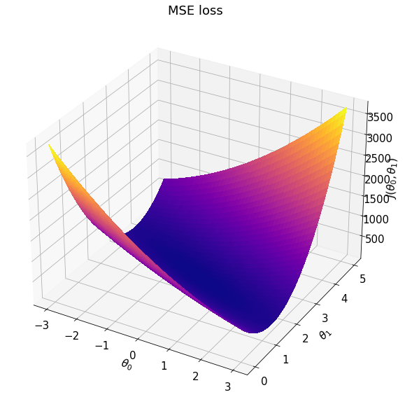

```python
fig = plt.figure(figsize=(15,10))
ax = fig.gca(projection='3d')
# Plot the surface.
surf = ax.plot_surface(theta0_mesh, theta1_mesh, J,linewidth=0, antialiased=False, cmap='plasma')
# Customize the z axis.
# ax.set_zlim(-1.01, 1.01)
plt.title('MSE loss')
plt.xlabel(r'$\theta_0$')
plt.ylabel(r'$\theta_1$')
ax.set_zlabel(r'$J(\theta_0, \theta_1)$')
plt.show()
```

### 3. (8 points) Graphical approach

To get the indices of the minimum elements of a N-dimensional array, we used `argmin` method.

```python
min_ind = np.unravel_index(np.argmin(J, axis=None), J.shape)
print("Minimum value of the cost function J is", J[min_ind[0]][min_ind[1]])
print("When [theta 0, theta 1] = ", [theta0[min_ind[0]], theta1[min_ind[1]]])
```

```
Minimum value of the cost function J is 0.3925612032282422
When [theta 0, theta 1] =  [-0.030303030303030276, 2.525252525252525]
```

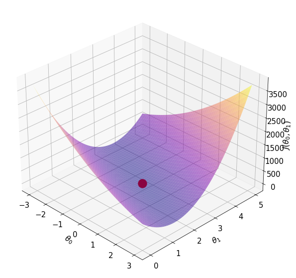

```python
fig = plt.figure(figsize=(15,10))
ax = fig.gca(projection='3d')
surf = ax.plot_surface(theta0_mesh, theta1_mesh, J,linewidth=0, antialiased=True, alpha=0.5, cmap='plasma')

plt.xlabel(r'$\theta_0$')
plt.ylabel(r'$\theta_1$')
ax.set_zlabel(r'$J(\theta_0, \theta_1)$')
ax.scatter(theta0[min_ind[0]], theta1[min_ind[1]], J[min_ind],'r', s=300, color = 'red')
ax.view_init(30, -45)
plt.show()
```

### 4. (10 points) Calculate $\theta_0$ and $\theta_1$ using the linear regression algorithm from Scikit-Learn package

```python
from sklearn.linear_model import LinearRegression
reg = LinearRegression().fit(x, y)
theta0_pred, theta1_pred = reg.intercept_[0], reg.coef_[0][0]
print("When (theta 0, theta 1) =", (theta0_pred, theta1_pred))
print("The regression score is", reg.score(x, y))
```

```
When (theta 0, theta 1) = (0.0014203115286064438, 2.496092823473767)
The regression score is 0.9969629687544361
```

### 5. (8 points) Calculate the optimal $\theta_0$ and $\theta_1$ using the analytical approach

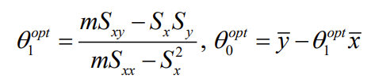

```python
Sx, Sy = x.sum(), y.sum()
Sxx = x.T @ x
Sxy = x.T @ y
theta_opt1 = (m*Sxy-Sx*Sy)/(m*Sxx-Sx**2)
theta_opt0 = y.mean() - theta_opt1*x.mean()
print("Using analytical method: (theta 0, theta 1) = ", (float(theta_opt0), float(theta_opt1)))
```

```
Using analytical method: (theta 0, theta 1) =  (0.0014203115286079981, 2.496092823473764)
```

### 6. (8 points) Compare the linear fitting curves obtained by the graphical approach, Sklearn package, and the analytical approach by plotting them on a single graph with the datapoints

```python
y_pred1 = theta0[min_ind[0]] + theta1[min_ind[1]] * x
y_pred2 = theta0_pred + theta1_pred * x
y_pred3 = theta_opt0 + theta_opt1 * x

def RMSE(y=y, y_pred=y_pred1):
  diff = y - y_pred
  temp = diff.T @ diff / y.size
  return float(np.sqrt(temp))

print('The root mean square error of graphical method: %.5f' %RMSE(y, y_pred1))
print('The root mean square error of Scikit-Learn package:%.5f' %RMSE(y, y_pred2))
print('The root mean square error of analytical method:%.5f' %RMSE(y, y_pred3))
```

```
The root mean square error of graphical method: 0.04430
The root mean square error of Scikit-Learn package:0.03997
The root mean square error of analytical method:0.03997
```

**RMSE(graphical method) > RMSE(Scikit_Learn) $\approx$ RMSE(analytical method)**

However, the difference between Scikit Learn and analytical method is very small $O(10^{-16})$, they are almost the same. But the root mean square error of graphical method is larger than those two, because the accuracy of graphical method mainly relies on the precision of parameter grid which is not high enough.

## Part (II) 2. Multivariate regression- Artificial Neural Networks

### 1. (6 points) Data exploration and visualization

```
First five entires out of 500 entries
      A      N     F     TTF
0  0.00  770.0  4.39     0.0
1  4.56  962.0  5.58  1220.0
2  6.27  703.0  5.60  2330.0
3  5.73  698.0  6.31  1530.0
4  4.87  688.0  5.71  1740.0
```

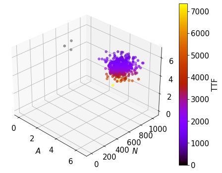

```python
df_2 = pd.read_csv(DATA_path_2)
A = df_2[['A']].values
N = df_2[['N']].values
F = df_2[['F']].values
TTF = df_2[['TTF']].values
m = A.size
print("First five entires out of",m,"entries")
print(df_2.head())
fig = plt.figure(figsize=(10,6))
ax = fig.gca(projection='3d')
plt.xlabel(r'$A$')
plt.ylabel(r'$N$')
ax.set_zlabel(r'$F$')
ax.view_init(30, -45)
sc = ax.scatter(A,N,F,c=TTF,cmap='gnuplot')
cb = plt.colorbar(sc)
cb.set_label('TTF')
plt.show()
```

We can see that there are several outliers. They meet the below criterion. TTF >3000. Also, we can see there are three gray dots on the left side of the figure. We can inspect this in details through data inspection.

### 2. (6 points) Data pre-processing, data cleaning

We just simply use `between` method to keep the data and discard the outliers.

```python
# remove outliners
df_2 = pd.read_csv(DATA_path_2)
TTF = df_2['TTF']
m = TTF.size
removed_outliers = TTF.between(TTF.quantile(.05), TTF.quantile(.95))
df_2 = df_2[removed_outliers].reset_index(drop=True)
A = df_2['A']
removed_outliers = A.between(A.quantile(.01), A.quantile(.99))
df_2 = df_2[removed_outliers].reset_index(drop=True)
N = df_2['N']
removed_outliers = N.between(N.quantile(.01), N.quantile(.99))
df_2 = df_2[removed_outliers].reset_index(drop=True)
# F = df_2['F']
# removed_outliers = F.between(F.quantile(.03), F.quantile(.97))
# df_2 = df_2[removed_outliers].reset_index(drop=True)

m_new= df_2['TTF'].size
print("We removed",m-m_new, "outliers.")
```

```
We removed 69 outliers.
```

### 3. (6 points) Data balance exploration

We can see most of the features follow normal distribution after removing the outliers. Some of the distribution might be skewed.

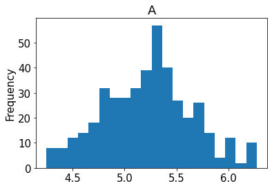

```python
df_2['A'].plot.hist(bins=20,title='A')
```

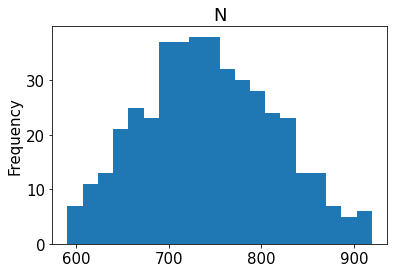

```python
df_2['N'].plot.hist(bins=20,title='N')
```

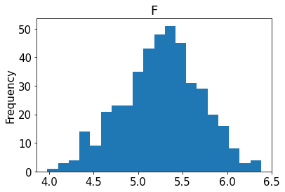

```python
df_2['F'].plot.hist(bins=20,title='F')
```

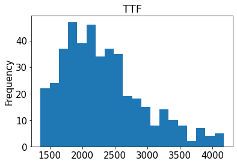

```python
df_2['TTF'].plot.hist(bins=20,title='TTF')
```

### 4. (6 points) Data normalization- Define a new dataframe, in which each column contains the z-score

```python
# z-score normalization (Standardization)
normalized_df = (df_2-df_2.mean())/df_2.std()

# save for future use
# reverse: normalized_df * std + mean
mean = df_2.mean()
std = df_2.std()

A = normalized_df[['A']].values
N = normalized_df[['N']].values
F = normalized_df[['F']].values
TTF = normalized_df[['TTF']].values
m = A.size
normalized_df.head()
```

|  | A | N | F | TTF |
| --- | --- | --- | --- | --- |
| 0 | 2.439062 | -0.569937 | 0.795151 | 0.010228 |
| 1 | 1.177579 | -0.640621 | 2.410528 | -1.286281 |
| 2 | -0.831449 | -0.781990 | 1.045421 | -0.945947 |
| 3 | 0.967332 | 0.037950 | 1.159180 | -0.832503 |
| 4 | 2.322258 | 1.055806 | 0.021590 | 0.139879 |

### 5. (6 points) Last check before prediction

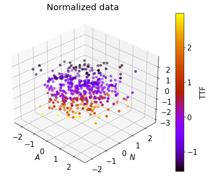

```python
fig = plt.figure(figsize=(10,6))
ax = fig.gca(projection='3d')
plt.xlabel(r'$A$')
plt.ylabel(r'$N$')
plt.title(r'Normalized data')
ax.set_zlabel(r'$F$')
ax.view_init(30, -45)
sc = ax.scatter(A,N,F,c=TTF,cmap='gnuplot')
cb = plt.colorbar(sc)
cb.set_label('TTF')
plt.show()
```

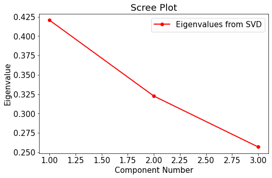

```python
mat = np.hstack((A, N))
mat = np.hstack((mat, F))

U, S, V = np.linalg.svd(mat)
eigvals = S**2 / np.sum(S**2)

fig = plt.figure(figsize=(8,5))
sing_vals = np.arange(3) + 1
plt.plot(sing_vals, eigvals, 'ro-', linewidth=2)
plt.title('Scree Plot')
plt.xlabel('Component Number')
plt.ylabel('Eigenvalue')
leg = plt.legend(['Eigenvalues from SVD'], loc='best')
plt.show()
```

### 6. (6 points) Data splitting

```python
import sklearn
ds_train, ds_test = sklearn.model_selection.train_test_split(normalized_df,test_size=0.2)
print("There are ",len(ds_train),"train sets and ",len(ds_test),"test sets.")
```

```
There are  344 train sets and  87 test sets.
```

### 7. (6 points) Linear Regression

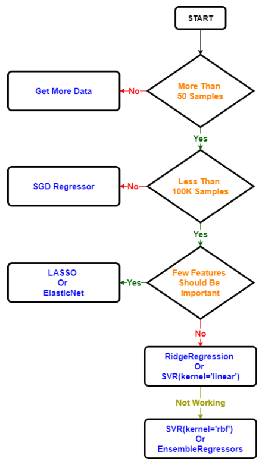

source : https://satishgunjal.com/multivariate_lr_scikit/

```python
from sklearn import linear_model
model_r = linear_model.Ridge(alpha=0.3)
X_train = pd.concat([ds_train["A"],ds_train["N"],ds_train["F"]], axis = 1, ignore_index=True)
y_train = ds_train["TTF"]
model_r.fit(X_train,y_train)
print('coeff= ' , model_r.coef_)
print('intercept= ' , model_r.intercept_)
```

```
coeff=  [ 0.30394867 -0.35431821 -0.97441096]
intercept=  0.004933062789906276
```

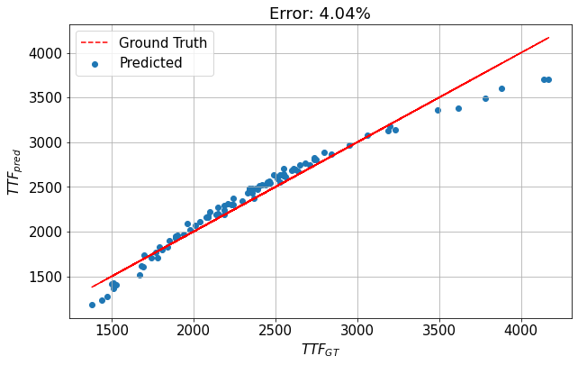

```python
X_test = pd.concat([ds_test["A"],ds_test["N"],ds_test["F"]], axis = 1, ignore_index=True)
y_test = ds_test["TTF"]
y_pred = model_r.predict(X_test)

y_test_denorm = y_test * std[-1] + mean[-1]
y_pred_denorm = y_pred * std[-1] + mean[-1]

def MAPE(y_true, y_pred):
    return np.mean(np.abs((y_true - y_pred) / y_true)) * 100

error = MAPE(y_test_denorm,y_pred_denorm)

fig= plt.figure(figsize=(10,6))
plt.title('Error: {:.2%}'.format(error/100))
plt.xlabel(r'$TTF_{GT}$')
plt.ylabel(r'$TTF_{pred}$')
plt.grid()
plt.scatter(y_test_denorm,y_pred_denorm,label='Predicted')
plt.plot(y_test_denorm,y_test_denorm,'r--',label='Ground Truth')
plt.legend()
plt.show()
```

The linear regression model succeed to achieve good predictions on the test-set.

```python
print('The error of prediction on testset is: {:.2%}'.format(error/100))
print('The success of prediction on testset is: {:.2%}'.format(1-error/100))
```

```
The error of prediction on testset is: 4.04%
The success of prediction on testset is: 95.96%
```

The regression model succeeded to achieve an acceptable predictions on the test-set. This model solves a regression model where the loss function is the linear least squares function and regularization is given by the l2-norm. It can be used as a multivariate regression model.

### 8. (8 points) Fully-connected deep neural network

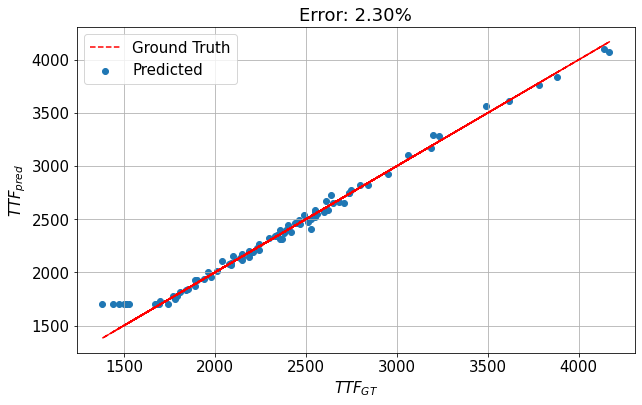

```
The success of prediction on testset is: 97.70%
```

```python
from sklearn.neural_network import MLPRegressor
MLP = MLPRegressor(hidden_layer_sizes=(64,64,1),
                   max_iter=250,
                   solver='adam',
                   alpha=0.001,
                   random_state=420,
                   n_iter_no_change=100,
                   verbose=False)

y_pred_MLP = MLP.fit(X_train, y_train).predict(X_test)
y_pred_MLP_denorm = y_pred_MLP * std[-1] + mean[-1]

error_MLP = MAPE(y_test_denorm,y_pred_MLP_denorm)

fig= plt.figure(figsize=(10,6))
plt.title('Error: {:.2%}'.format(error_MLP/100))
plt.xlabel(r'$TTF_{GT}$')
plt.ylabel(r'$TTF_{pred}$')
plt.grid()
plt.scatter(y_test_denorm,y_pred_MLP_denorm,label='Predicted')
plt.plot(y_test_denorm,y_test_denorm,'r--',label='Ground Truth')
plt.legend()
plt.show()
print('The success of prediction on testset is: {:.2%}'.format(1-error_MLP/100))
```